# N5 Prelim Revision Booklet - Web Version

## Factorising

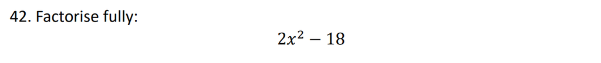

There are three kinds of factorising to consider in turn: *common factor*, *difference of two squares* and *trinomials/double brackets*. Sometimes more than one kind is needed in a single factorising question.

$2(x+3)(x-3)$

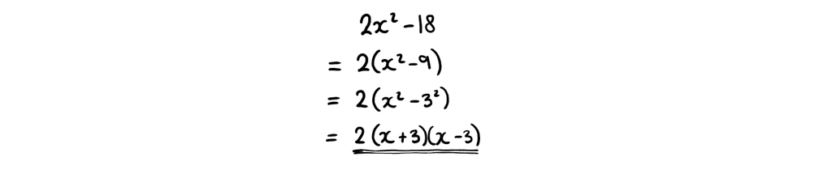

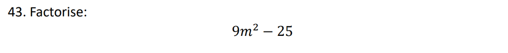

$9m^2$ can be written as $(\dots)^2$?

$(3m+5)(3m-5)$

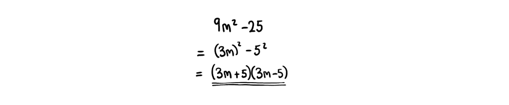

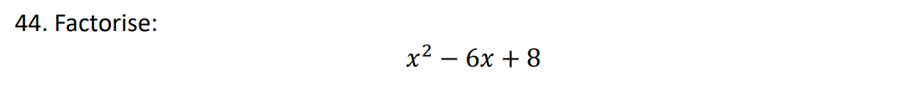

*"Think of two numbers that multiple to give... and add to give..."*

$(x-4)(x-2)$

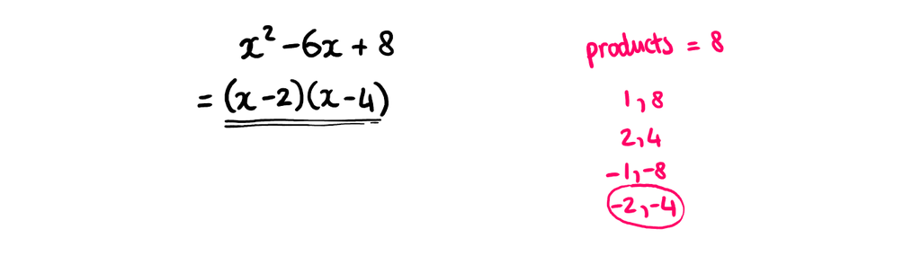

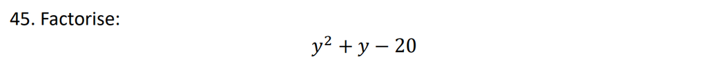

It can help to write out all of the possible pairs of whole numbers that *multiply to give -20*.

$(y+5)(y-4)$

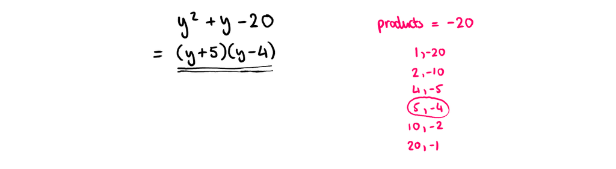

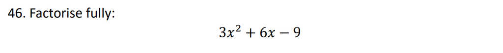

Always look to take a *common factor* first. However, there may still be *more to do* afterwards...

$3(x+3)(x-1)$

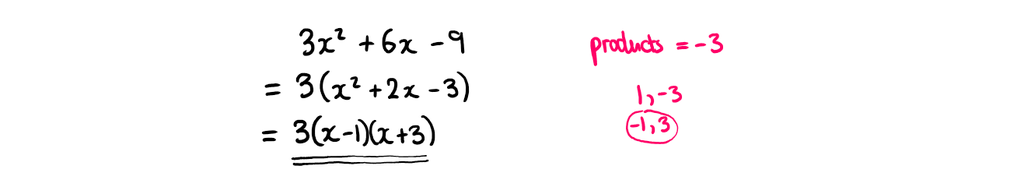

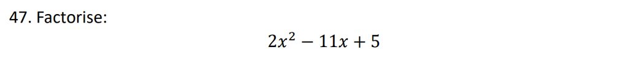

One approach is to find a pair of numbers that multiply to give 5, but that add to give -11 *when one of them is multiplied by 2 first.*

$(2x-1)(x-5)$

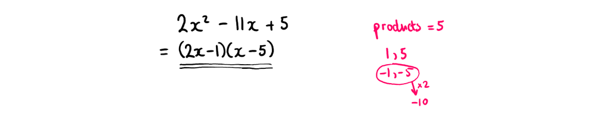

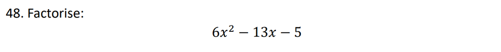

Trying to find numbers for a solution of the form $(6x...)(x...)$ is a good place to start, but it won't work.

When that fails, try looking for a solution of the form $(3x...)(2x...)$. This means we need numbers which **multiply** to give $-5$, which also add to give $-13$ when *one of them is tripled* and *one of them is doubled*.

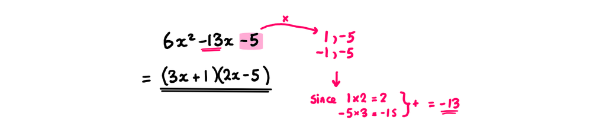

## Statistics

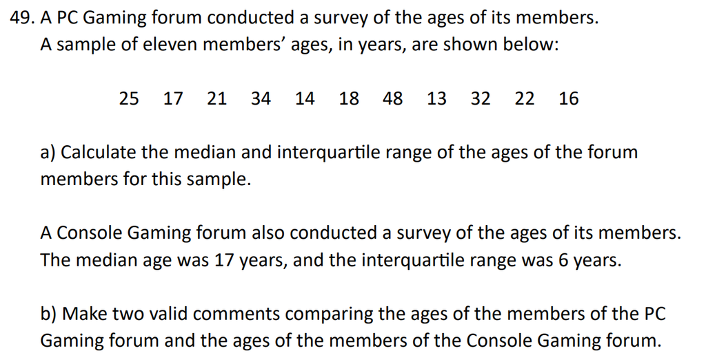

Start by putting the numbers *in order*...

1. Median = 21, interquartile range = 16.
2. Compare your comments to those in the solution, or ask your teacher to check them.

[figure not shown]

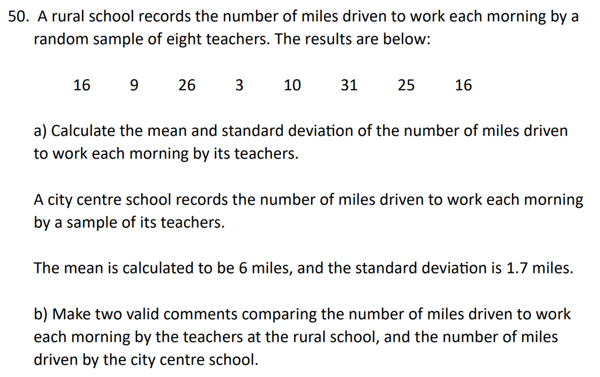

There are *two formulae* on the formula sheet for standard deviation. Check your notes to see *which one* your teacher taught you how to use.

1. Mean = 17, standard deviation = 9.7.
2. Compare your comments to those in the solution, or ask your teacher to check them.

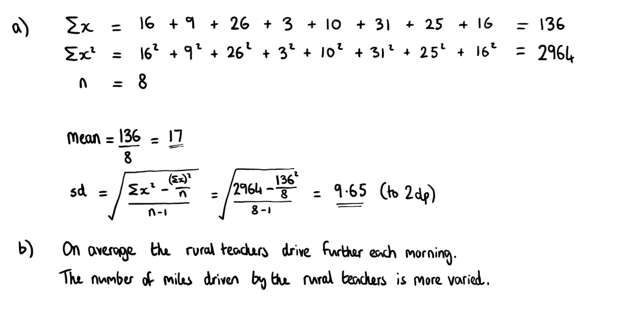

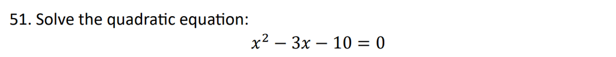

To solve a quadratic equation, you will usually want to *factorise* first.

$x=-2,x=5$

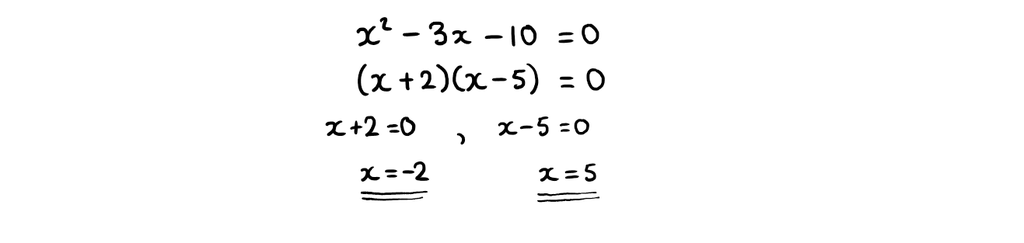

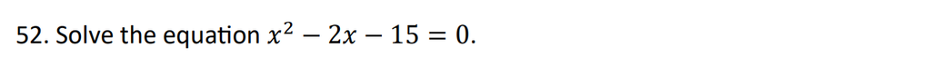

First factorise the left hand side.

$x=-3,x=5$

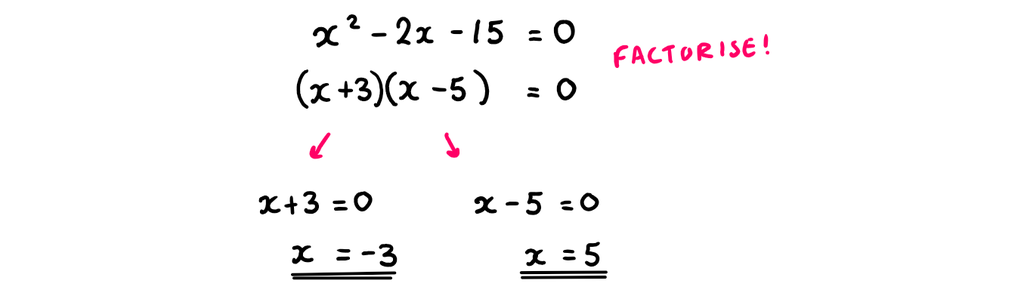

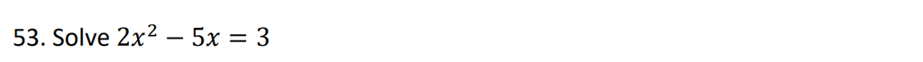

First rearrange the quadratic equation to the form $...=0$.

$x=-\frac{1}{2},x=3$

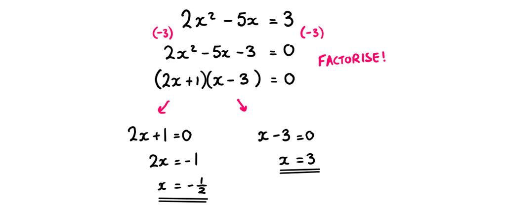

## Arcs and Sectors

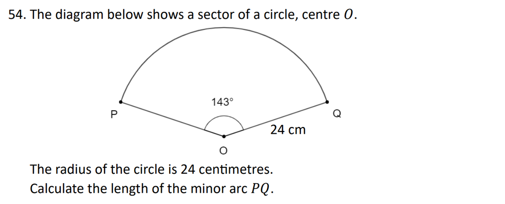

An arc is a *fraction of a circumference*.

$59.9\text{ cm}$

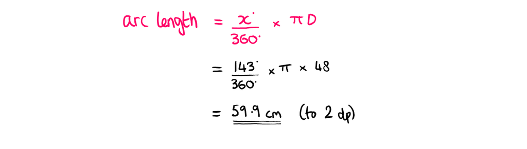

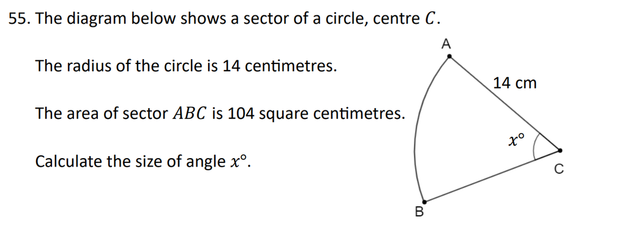

This is another example of substituting into a formula then *rearranging*.

$60.8^{\circ}$

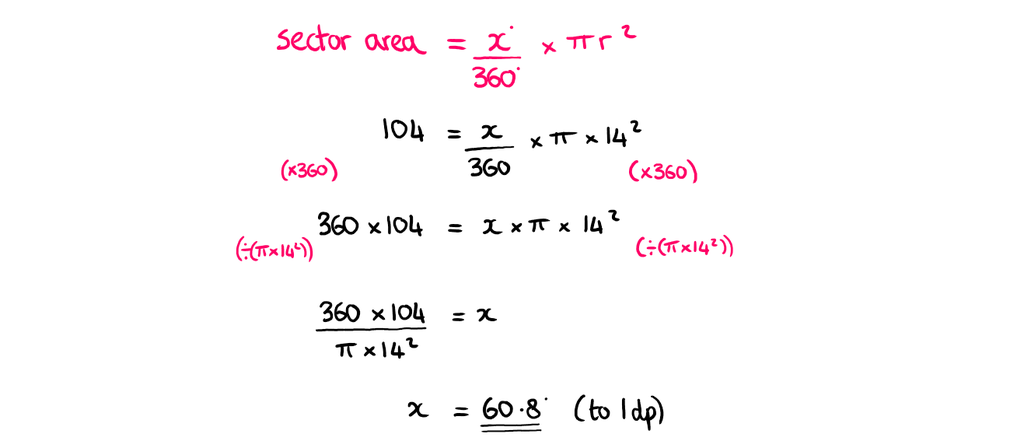